# Chapter2 Statistics-Quantitaive Variables : Ravi Mummigatti : 24-12-20

# Goal

Numerical summaries are useful when we have a large amount of data and want to condense it down to a few numbers that provide insights into an entire dataset.While numerical summaries can only tell us so much about our data , sometimes, we need visualizations to dig deeper or interpret summary statistics. Visualizations can also help us choose appropriate summary statistics for things we want to measure about our data.

At the end of this module, you will be able to:  
**Interpret and calculate the following statistics in Python:**

- Mean (or average)
- Median
- Mode
- Variance
- Standard deviation

**Interpret and calculate the following additional summary statistics for spread:**

- Quartiles
- Quantiles
- Inter-Quartile Range

**Interpret and create the following visualizations in python:**

- Histogram
- Box Plot

**Prerequisites : Basic knowledge of Python and Pandas**

# Introduction

Numerical summaries are useful when we have a large amount of data and want to condense it down to a few numbers that provide insights into an entire dataset.  
Descriptive statistics is a study of data analysis to describe, show or summarize data in a meaningful way. It involves the calculation of various measures such as the **measure of center, the measure of variability, percentiles and also the construction of tables & graphs**

# Location: Mean-Average

Finding the center of a dataset is one of the most common ways to summarize statistical findings. Often, people communicate the center of data using words like, on average, usually, or often.

**The mean, often referred to as the average, is a way to measure the center of a dataset.**
$${\displaystyle \bar{x}={\frac {1}{n}}\sum _{i=1}^{n}x_{i}={\frac {x_{1}+x_{2}+\cdots +x_{n}}{n}}}$$

The equation above is used to calculate mean. x1, x2, … xn are observations from a dataset of n observations

We collected the dataset "tophundredbooks" from a survey administered by the French literary magazine, Le Monde.  
From the dataset, you will calculate the average age of the authors when their books were published.

**Calculating Mean Manually**  
In this exercise, you will use Python to find the average age of the first four authors in Le Monde’s top 100 books. {29,49,42,43}

```python
# Set total equal to the sum
total = 29+49+42+43

# Set mean_value equal to the mean
mean_value = total/4

# The following code prints the total and mean
print("The sum total is equal to: " + str(total))
print("The mean value is equal to: " + str(mean_value))
```

```
The sum total is equal to: 163
The mean value is equal to: 40.75
```

**Calculating Mean with Numpy**  
The NumPy **.average()** or **.mean()** function can do the work of adding and dividing for you

```python
# import pandas and numpy
import pandas as pd
import numpy as np

# Read author data
greatest_books = pd.read_csv("tophundredbooks.csv")

# Set author ages to a NumPy array
author_ages = greatest_books['Ages']

# Use numpy to calculate the average age of the top 100 authors
average_age = np.mean(author_ages)

# print the result
print("The average age of the 100 greatest authors, according to a survey by Le Monde, is: " + str(average_age))
```

```
The average age of the 100 greatest authors, according to a survey by Le Monde, is: 42.12
```

# Location : Median-Center

The formal definition for the median of a dataset is:  
**The value that, assuming the dataset is ordered from smallest to largest, falls in the middle. If there are an even number of values in a dataset, you either report both of the middle two values or their average.**

**Calculating Median Manually**

```python
# Array of the first five author ages
five_author_ages = np.array([29, 49, 42, 43, 32])

# Fill in the empty array with the values sorted
sorted_author_ages = np.array([29,32,42,43,49])

# Save the median value to median_value
median_age = 42

# Print the sorted array and median value
print("The sorted array is: " + str(sorted_author_ages))
print("The median of the array is: " + str(median_age))
```

```
The sorted array is: [29 32 42 43 49]
The median of the array is: 42
```

```python
# Array of the first five author ages
six_author_ages = np.array([29, 49, 42, 43, 32 , 40])

# Fill in the empty array with the values sorted
sorted_author_ages = np.array([29,32,40,42,43,49])

# Save the median value to median_value
median_age = (40+42)/2

# Print the sorted array and median value
print("The sorted array is: " + str(sorted_author_ages))
print("The median of the array is: " + str(median_age))
```

```
The sorted array is: [29 32 40 42 43 49]
The median of the array is: 41.0
```

**Calculating Median with Numpy**  
The NumPy .median() function can do the work of sorting, then finding the median for us

```python
# import pandas and numpy
import pandas as pd
import numpy as np

# Read author data
greatest_books = pd.read_csv("tophundredbooks.csv")

# Set author ages to a NumPy array
author_ages = greatest_books['Ages']

# Use numpy to calculate the average age of the top 100 authors
median_age = np.median(author_ages)

# print the result
print("The median age of the 100 greatest authors, according to a survey by Le Monde, is: " + str(median_age))
```

```
The median age of the 100 greatest authors, according to a survey by Le Monde, is: 41.0
```

# Location : Mode : Most Common

The formal definition for the mode of a dataset is:  
**The most frequently occurring observation in the dataset.**  
A dataset can have multiple modes if there is more than one value with the same maximum frequency.

**Calculating Mode Manually**

```python
import numpy as np

# Set first_ten_authors equal to their ages
first_ten_authors = np.array([29, 49, 42, 43, 32, 38, 37, 41, 27, 27])

# Save the mode value to mode_age (most frequent value is 27)
mode_age = 27

# Save the count of authors with the mode age (frequency of 27 is 2)
mode_count = 2

# Print the sorted array and median value
print("The ages of the first ten authors is: " + str(first_ten_authors))
print("The mode of the first ten authors is: " + str(mode_age))
print("The number of authors who were " + str(mode_age) + " when their book was published is " + str(mode_count))
```

```
The ages of the first ten authors is: [29 49 42 43 32 38 37 41 27 27]
The mode of the first ten authors is: 27
The number of authors who were 27 when their book was published is 2
```

**Calculating Mode : Scipy : stats.mode()**  
The SciPy **stats.mode()** function can do the work of finding the mode for us.  
The result of stats.mode() is an object with the smallest mode value, and its count.  
...example_mode ModeResult(mode=array([12]), count=array([3]))

```python
# Import packages
import numpy as np
import pandas as pd
from scipy import stats

# Read in author data
greatest_books = pd.read_csv("tophundredbooks.csv")

# Save author ages to author_ages
author_ages = greatest_books['Ages']

# Use numpy to calculate the mode age of the top 100 authors
mode_age = stats.mode(author_ages)

print("The mode age and its frequency of authors from Le Monde's 100 greatest books is: " +
      str(mode_age[0][0]) + " and " + str(mode_age[1][0]))
```

```
The mode age and its frequency of authors from Le Monde's 100 greatest books is: 38 and 7
```

# Plotting Mean-Median-Mode

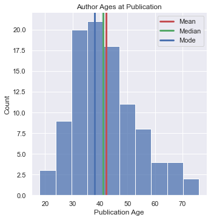

```
The average age of the 100 greatest authors, according to a survey by Le Monde, is: 42.12
The median age of the 100 greatest authors, according to a survey by Le Monde, is: 41.0
The most common age of the 100 greatest authors, according to a survey by Le Monde, is: 38
```

```python
#Import packages
import numpy as np
import pandas as pd
from scipy import stats

# Import matplotlib pyplot
from matplotlib import pyplot as plt
import seaborn as sns
sns.set()

# Read in transactions data
greatest_books = pd.read_csv("tophundredbooks.csv")

# Save transaction times to a separate numpy array
author_ages = greatest_books['Ages']

# Calculate the average and median value of the author_ages array
average_age = np.average(author_ages)
median_age = np.median(author_ages)
mode_age = 38

# Plot the figure
sns.displot(author_ages)
plt.title("Author Ages at Publication")
plt.xlabel("Publication Age")
plt.ylabel("Count")
plt.axvline(average_age, color='r', linestyle='solid', linewidth=3, label="Mean")
plt.axvline(median_age, color='g', linestyle='solid', linewidth=3, label="Median")
plt.axvline(mode_age, color='b', linestyle='solid', linewidth=3, label="Mode")
plt.legend()

plt.show();
print("The average age of the 100 greatest authors, according to a survey by Le Monde, is: " + str(average_age))
print("The median age of the 100 greatest authors, according to a survey by Le Monde, is: " + str(median_age))
print("The most common age of the 100 greatest authors, according to a survey by Le Monde, is: " + str(mode_age))
```

```python
arr = np.array([10,13,7,10,5,15])
```

```python
np.mean(arr)
```

```
10.0
```

```python
np.median(arr)
```

```
10.0
```

```python
stats.mode(arr)
```

```
ModeResult(mode=array([10]), count=array([2]))
```

# Project : Central Tendency for Housing Data

In this project, we will find the mean, median, and mode cost of one-bedroom apartments in three of the five New York City boroughs: Brooklyn, Manhattan, and Queens.

Using our findings, we will make conclusions about the cost of living in each of the boroughs. We will also discuss an important assumption that we make when we point out differences between the boroughs.

Streeteasy.com is the source from where we collected this data. While we will only focus on the cost of one-bedroom apartments, the dataset includes a lot more information about the Brooklyn, Manhattan, and Queens housing market.

**Observing your Data**  
Import data about one-bedroom apartments in three of New York City’s boroughs: Brooklyn, Manhattan, and Queens and save the values to:

- brooklyn_one_bed
- manhattan_one_bed
- queens_one_bed

Since we only care about the price of apartments, so we need to save the price of apartments in each borough to:

- brooklyn_price
- manhattan_price
- queens_price

```python
# import the required libraries
import pandas as pd
import numpy as np
from scipy import stats

# print multiple lines at the same time
from IPython.core.interactiveshell import InteractiveShell
InteractiveShell.ast_node_interactivity = "all"
```

```python
# import the data sets
brooklyn = pd.read_csv("broklyn_one_bed.csv")
manhattan = pd.read_csv("manhattan_one_bed.csv")
queens = pd.read_csv("queens_one_bed.csv")
```

```python
# inspect top rows
brooklyn.head(2)
manhattan.head(2)
queens.head(2)
```

|  | rental_id | rent | bedrooms | bathrooms | size_sqft | min_to_subway | floor | building_age_yrs | no_fee | has_roofdeck | has_washer_dryer | has_doorman | has_elevator | has_dishwasher | has_patio | has_gym | neighborhood | borough |
| --- | --- | --- | --- | --- | --- | --- | --- | --- | --- | --- | --- | --- | --- | --- | --- | --- | --- | --- |
| 0 | 24 | 4900 | 1 | 1 | 1216 | 6 | 3 | 88 | 0 | 0 | 0 | 0 | 0 | 0 | 0 | 0 | Brooklyn Heights | Brooklyn |
| 1 | 849 | 2750 | 1 | 1 | 700 | 12 | 3 | 9 | 1 | 0 | 0 | 0 | 0 | 0 | 0 | 0 | Clinton Hill | Brooklyn |

|  | rental_id | rent | bedrooms | bathrooms | size_sqft | min_to_subway | floor | building_age_yrs | no_fee | has_roofdeck | has_washer_dryer | has_doorman | has_elevator | has_dishwasher | has_patio | has_gym | neighborhood | borough |
| --- | --- | --- | --- | --- | --- | --- | --- | --- | --- | --- | --- | --- | --- | --- | --- | --- | --- | --- |
| 0 | 2919 | 4500 | 1 | 1 | 916 | 2 | 51 | 29 | 0 | 1 | 0 | 1 | 1 | 1 | 0 | 0 | Midtown | Manhattan |
| 1 | 2790 | 4795 | 1 | 1 | 975 | 3 | 8 | 31 | 0 | 0 | 0 | 1 | 1 | 1 | 0 | 1 | Greenwich Village | Manhattan |

|  | rental_id | rent | bedrooms | bathrooms | size_sqft | min_to_subway | floor | building_age_yrs | no_fee | has_roofdeck | has_washer_dryer | has_doorman | has_elevator | has_dishwasher | has_patio | has_gym | neighborhood | borough |
| --- | --- | --- | --- | --- | --- | --- | --- | --- | --- | --- | --- | --- | --- | --- | --- | --- | --- | --- |
| 0 | 10524 | 1950 | 1 | 1 | 950 | 1 | 3 | 83 | 0 | 0 | 0 | 0 | 0 | 0 | 0 | 0 | Forest Hills | Queens |
| 1 | 5465 | 3500 | 1 | 1 | 996 | 9 | 7 | 3 | 1 | 0 | 0 | 0 | 0 | 0 | 0 | 0 | Astoria | Queens |

```python
# select only rent columns from each data set
b_rent = brooklyn['rent']
m_rent = manhattan['rent']
q_rent = queens['rent']

# inspect the new data sets
b_rent.head(2)
m_rent.head(2)
q_rent.head(2)
```

```
0    4900
1    2750
Name: rent, dtype: int64
```

```
0    4500
1    4795
Name: rent, dtype: int64
```

```
0    1950
1    3500
Name: rent, dtype: int64
```

**Find the Mean , Median and Mode**

- brooklyn_mean , brooklyn_median , brooklyn_mode
- manhattan_mean , manhattan_median , manhattan_mode
- queens_mean , queens _median , queens _mod

```python
brooklyn_mean = np.mean(b_rent)
print("The average rent in Brooklyn is : " + str(brooklyn_mean))

manhattan_mean = np.mean(m_rent)
print("The average rent in Manhattan is : " + str(manhattan_mean))

queens_mean = np.mean(q_rent)
print("The average rent in Queens is : " + str(queens_mean))
```

```
The average rent in Brooklyn is : 2784.855882352941
The average rent in Manhattan is : 3993.4769647696476
The average rent in Queens is : 2346.2543103448274
```

```python
brooklyn_median = np.median(b_rent)
print("The median rent in Brooklyn is : " + str(brooklyn_median))

manhattan_median = np.mean(m_rent)
print("The median rent in Manhattan is : " + str(manhattan_median))

queens_median = np.median(q_rent)
print("The median rent in Queens is : " + str(queens_median))
```

[output not shown]

```python
brooklyn_mode = stats.mode(b_rent)
print("The mode age and its frequency of one bed appartments in Brooklyn: " +
      str(brooklyn_mode[0][0]) + " and " + str(brooklyn_mode[1][0]))


manhattan_mode = stats.mode(m_rent)
print("The mode age and its frequency of one bed appartments in Manhattan: " +
      str(manhattan_mode[0][0]) + " and " + str(manhattan_mode[1][0]))

queens_mode = stats.mode(q_rent)
print("The mode age and its frequency of one bed appartments in Queens: " +
      str(queens_mode[0][0]) + " and " + str(queens_mode[1][0]))
```

```
The mode age and its frequency of one bed appartments in Brooklyn: 2200 and 12
The mode age and its frequency of one bed appartments in Manhattan: 3500 and 56
The mode age and its frequency of one bed appartments in Queens: 1750 and 11
```

**Inference : Manhattan is the most expensive location for renting a "one-bed" apartment with the highest number of dwellings whilst Queens is the cheapest with the least number of dwellings**

**Visualizing The Data**

```python
# select only rent columns from each data set
b_rent = brooklyn['rent']
m_rent = manhattan['rent']
q_rent = queens['rent']
```

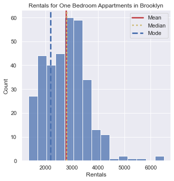

```python
# Plot Histogram of Brooklyn Rentals
# Calculate the Mean Median and Mode
b_avg = np.mean(b_rent)
b_med = np.median(b_rent)
b_mode = 2200

# Plot the figure
sns.displot(b_rent , bins = 15)
plt.title("Rentals for One Bedroom Appartments in Brooklyn")
plt.xlabel("Rentals")
plt.ylabel("Count")
plt.axvline(b_avg, color='r', linestyle='solid', linewidth=3, label="Mean")
plt.axvline(b_med, color='y', linestyle='dotted', linewidth=3, label="Median")
plt.axvline(b_mode, color='b', linestyle='dashed', linewidth=3, label="Mode")
plt.legend()

plt.show();
```

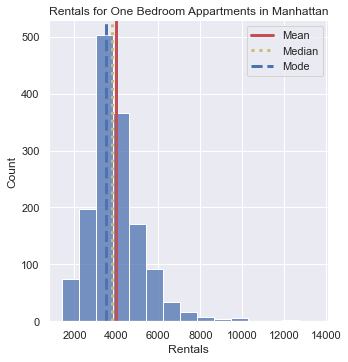

```python
# Plot Histogram of Manhattan Rentals
# Calculate the Mean , Median and Mode
m_avg = np.mean(m_rent)
m_med = np.median(m_rent)
m_mode = 3500

# Plot the figure
sns.displot(m_rent , bins = 15)
plt.title("Rentals for One Bedroom Appartments in Manhattan")
plt.xlabel("Rentals")
plt.ylabel("Count")
plt.axvline(m_avg, color='r', linestyle='solid', linewidth=3, label="Mean")
plt.axvline(m_med, color='y', linestyle='dotted', linewidth=3, label="Median")
plt.axvline(m_mode, color='b', linestyle='dashed', linewidth=3, label="Mode")
plt.legend()

plt.show();
```

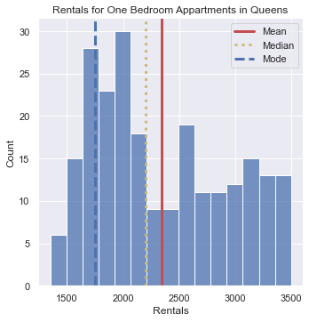

```python
# Plot Histogram of Queens Rentals
# Calculate the Mean , Median and Mode
q_avg = np.mean(q_rent)
q_med = np.median(q_rent)
q_mode = 1750

# Plot the figure
sns.displot(q_rent,bins=15)
plt.title("Rentals for One Bedroom Appartments in Queens")
plt.xlabel("Rentals")
plt.ylabel("Count")
plt.axvline(q_avg, color='r', linestyle='solid', linewidth=3, label="Mean")
plt.axvline(q_med, color='y', linestyle='dotted', linewidth=3, label="Median")
plt.axvline(q_mode, color='b', linestyle='dashed', linewidth=3, label="Mode")
plt.legend()

plt.show();
```

# Variability : Variance

Finding the mean, median, and mode of a dataset is a good way to start getting an understanding of the general shape of your data

However, those three descriptive statistics only tell part of the story. Consider the two datasets below:

dataset_one = [-4, -2, 0, 2, 4]  
dataset_two = [-400, -200, 0, 200, 400]

These two datasets have the same mean and median — both of those values happen to be 0.  
If we only reported mean and median, we would not be communicating any meaninful difference between these two datasets.

This is where variance comes into play.  
**Variance is a descriptive statistic that describes how spread out the points in a data set are.**

We have leanred how to capture the "spread / central tendency" of the data with a single number "mean-median-mode"..

We will now attempt to capture the spread of the data in a single number "variance"

Let’s start with our intuition — we want the variance of a dataset to be a large number if the data is spread out, and a small number if the data is close together.

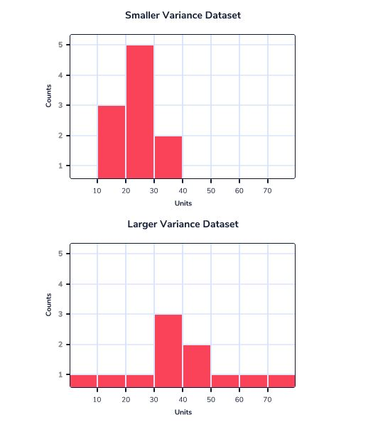

A lot of people may initially consider using the range of the data. But that only considers two points in your entire dataset. Instead, we can include every point in our calculation by finding the difference between every data point and the mean

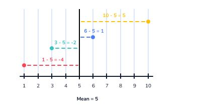

If the data is close together, then each data point will tend to be close to the mean, and the difference will be small. If the data is spread out, the difference between every data point and the mean will be larger.

Mathematically, we can write this comparison as : **difference=X−μ**  
Where X is a single data point and the Greek letter mu is the mean.

**Calculating Variance Manually**  
We’ve been given a very small dataset of five values named grades. These are five randomly chosen grades from the first teacher’s class. We’ve also calculated the mean of this small dataset and stored it in a variable named mean.

**Step 1 :** Find the difference between each of these data points and the mean.

```python
import numpy as np

grades = [88, 82, 85, 84, 90]
mean = np.mean(grades)

difference_one = grades[0]-mean
difference_two = grades[1]-mean
difference_three = grades[2]-mean
difference_four = grades[3]-mean
difference_five = grades[4]-mean


# Printing the output
print("The mean of the data set is " + str(mean) + "\n")
print("The first student is " +str(round(difference_one, 2)) + " percentage points away from the mean.")
print("The second student is " +str(round(difference_two, 2)) + " percentage points away from the mean.")
print("The third student is " +str(round(difference_three, 2)) + " percentage points away from the mean.")
print("The fourth student is " +str(round(difference_four, 2)) + " percentage points away from the mean.")
print("The fifth student is " +str(round(difference_five, 2)) + " percentage points away from the mean.")
```

```
The mean of the data set is 85.8

The first student is 2.2 percentage points away from the mean.
The second student is -3.8 percentage points away from the mean.
The third student is -0.8 percentage points away from the mean.
The fourth student is -1.8 percentage points away from the mean.
The fifth student is 4.2 percentage points away from the mean.
```

We now have five different values that describe how far away each point is from the mean. That seems to be a good start in describing the spread of the data. But the whole point of calculating variance was to get one number that describes the dataset. We don’t want to report five values — we want to combine those into one descriptive statistic.

To do this, we’ll take the average of those five numbers. By adding those numbers together and dividing by 5, we’ll end up with a single number that describes the average distance between our data points and the mean.

**Step 2 :** Finding the sum of differences of each value to the mean  
**Step 3 :** Finding the average of the sum of differences of each value to the mean

```python
#Part 1: Sum the differences
difference_sum = difference_one + difference_two + difference_three + difference_four+ difference_five

#Part 2: Average the differences
average_difference = difference_sum / 5

#Print the values
print("The sum of the differences is " + str(format(difference_sum, "f")))
print("The average difference is " + str(format(average_difference, "f")))
```

```
The sum of the differences is 0.000000
The average difference is 0.000000
```

**Sum of Differences to the mean is "0" so also the Average of the Sum of Difference to the mean is "0"!!!**

**Step 4:** Square The Differences  
We have one small problem with our equation **difference=X−μ**.

Consider this very small dataset: [-5, 5]

The mean of this dataset is 0, so when we find the difference between each point and the mean we get -5 - 0 = -5 and 5 - 0 = 5.

When we take the average of -5 and 5 to get the variance, we get 0!

Now think about what would happen if the dataset were [-200, 200]. We’d get the same result! That can’t possibly be right — the dataset with 200 is much more spread out than the dataset with 5, so the variance should be much larger!

The problem here is with negative numbers. Because one of our data points was 5 units below the mean and the other was 5 units above the mean, they canceled each other out!

**When calculating variance, we don’t care if a data point was above or below the mean — all we care about is how far away it was. To get rid of those pesky negative numbers, we’ll square the difference between each data point and the mean.**

Our equation for finding the difference between a data point and the mean now looks like this: **difference=$({X} - \mu)^2$**

**Step 5:** Divide Sum of Square of Differences to mean by number of observations

**Variance = (Sum of Square of Differences of each observation to the mean) / # of observations**

*Square each of the values stored in the variables difference_one through difference_five*

```python
grades = [88, 82, 85, 84, 90]
mean = np.mean(grades)

#When calculating these variables, square the difference.
difference_one = (88 - mean)**2
difference_two = (82 - mean)**2
difference_three = (85 - mean)**2
difference_four = (84 - mean)**2
difference_five = (90 - mean)**2

difference_sum = difference_one + difference_two + difference_three + difference_four + difference_five

variance = difference_sum / 5

print("The sum of the squared differences is " + str(difference_sum))
print("The variance is " + str(variance))
```

```
The sum of the squared differences is 40.8
The variance is 8.16
```

**Variance with Numpy : np.var()**
The full equation for the variance is as follows:
**$$\sigma^2 = \frac{\sum\limits_{i=1}^N (X -\mu)^2}{N}$$**

Variance is usually represented by the symbol sigma squared.  
We start by taking every point in the dataset — from point number 1 to point number N — and finding the difference between that point and the mean.  
Next, we square each difference to make all differences positive.  
Finally, we average those squared differences by adding them together and dividing by N, the total number of points in the dataset.

All of this work can be done quickly using the var(0 function from Python’s NumPy library.

```python
import numpy as np

dataset = [3, 5, -2, 49, 10]
variance = np.var(dataset)
variance
```

```
338.8
```

We’ve created two datasets Teacher_one and Teacher_two Grades.  
Plotted histogram of the two datasets on the same graph to help visualize the difference in spread. Calculated the Variance of the two datasets.

```
Variance of Teacher One Scores = 4.27
Variance of Teacher two Grades = 78.13
```

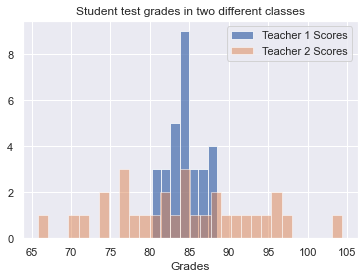

```python
import matplotlib.pyplot as plt
import seaborn

teacher_one_grades = [80.24, 81.15, 81.29, 82.12, 82.52, 82.54, 82.76, 83.37, 83.42, 83.45, 83.47, 83.79, 83.91, 83.98, 84.03, 84.69, 84.74, 84.89, 84.95, 84.95, 85.02, 85.18, 85.53, 86.29, 86.83, 87.29, 87.47, 87.62, 88.04, 88.5]
teacher_two_grades = [65.82, 70.77, 71.46, 73.63, 74.62, 76.53, 76.86, 77.06, 78.46, 79.81, 80.64, 81.61, 81.84, 83.67, 84.44, 84.73, 84.74, 85.15, 86.55, 88.06, 88.53, 90.12, 91.27, 91.62, 92.86, 94.37, 95.64, 95.99, 97.69, 104.4]

#Set these two variables equal to the variance of each dataset using NumPy
teacher_one_variance = np.var(teacher_one_grades)
teacher_two_variance = np.var(teacher_two_grades)

print("Variance of Teacher One Scores = " + str(round(teacher_one_variance,2)))
print("Variance of Teacher two Grades = " + str(round(teacher_two_variance,2)))

#Plot the histograms
plt.hist(teacher_one_grades, alpha = 0.75, label = "Teacher 1 Scores", bins = 7)
plt.hist(teacher_two_grades, alpha = 0.5, label = "Teacher 2 Scores", bins = 30)
plt.title("Student test grades in two different classes")
plt.xlabel("Grades")
plt.legend()
plt.show();
```

In addition to comparing Histograms , Variance is useful because it is a measure of spread.  
While we might get a general understanding of the spread by looking at a histogram, computing the variance gives us a numerical value that helps us describe the level of confidence of our comparison. It is also interesting to consider datasets that don’t have the same general curve>

# Variability : Standard Deviation

When beginning to work with a dataset, one of the first pieces of information you might want to investigate is the spread — is the data close together or far apart? One of the tools in our statistics toolbelt to do this is the descriptive statistic variance. **$$\sigma^2 = \frac{\sum\limits_{i=1}^N (X -\mu)^2}{N}$$** Variance is a tricky statistic to use because its units are different from both the mean and the data itself.
Since the formula for variance includes squaring the difference between the data and the mean, the variance is measured in units squared.This result is hard to interpret in context with the mean or the data because their units are different. This is where the statistic standard deviation is useful...

**Standard deviation is computed by taking the square root of the variance.**
$\sigma$ is the symbol commonly used for standard deviation.
Conveniently, sigma squared is the symbol commonly used for variance: **$$\sigma = \sqrt\sigma^2 = \sqrt\frac{\sum\limits_{i=1}^N (X -\mu)^2}{N}$$**

**Calculating SD Manually**

```python
import numpy as np
import pandas as pd
ok_nba_data = pd.read_csv("nba_ok_data.csv")
ok_nba_data.head()
```

|  | obs_num | nba | cupid |
| --- | --- | --- | --- |
| 0 | 1 | 82 | 75 |
| 1 | 2 | 81 | 70 |
| 2 | 3 | 86 | 68 |
| 3 | 4 | 73 | 71 |
| 4 | 5 | 78 | 66 |

```python
# Calculate the variances
nba_variance = np.var(ok_nba_data["nba"])
okcupid_variance = np.var(ok_nba_data["cupid"])

# Calculate the standard deviation of each dataset.
nba_standard_deviation = np.round(nba_variance**0.5,2)
okcupid_standard_deviation = np.round(okcupid_variance**0.5,2)

# Print
print("The standard deviation of the NBA dataset is " + str(nba_standard_deviation))
print("The standard deviation of the OkCupid dataset is " + str(okcupid_standard_deviation))
```

```
The standard deviation of the NBA dataset is 3.65
The standard deviation of the OkCupid dataset is 3.92
```

**Calculating S.D. : Numpy : np.std()**  
There is a NumPy function dedicated to finding the standard deviation of a dataset — we can cut out the step of first finding the variance.  
The NumPy function std() takes a dataset as a parameter and returns the standard deviation of that dataset

```python
#Calculating standard deviation of each dataset using np.std()
nba_standard_deviation = np.round(np.std(ok_nba_data["nba"]),2)
okcupid_standard_deviation = np.round(np.std(ok_nba_data["cupid"]),2)

#IGNORE CODE BELOW HERE
print("The standard deviation of the NBA dataset is " +str(nba_standard_deviation))
print("The standard deviation of the OkCupid dataset is " + str(okcupid_standard_deviation))
```

```
The standard deviation of the NBA dataset is 3.65
The standard deviation of the OkCupid dataset is 3.92
```

**Using Standard Deviation**

Now that our units match, our measure of spread is easier to interpret.By finding the number of standard deviations a data point is away from the mean, we can begin to investigate how unusual that datapoint truly is.

In fact, you can usually expect around 68% of your data to fall within one standard deviation of the mean, 95% of your data to fall within two standard deviations of the mean, and 99.7% of your data to fall within three standard deviations of the mean.

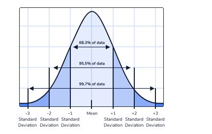

# Visualizing Quantitative Data

Numerical summaries can only tell us so much about our data. Sometimes, we need visualizations to dig deeper or interpret summary statistics. Visualizations can also help us choose appropriate summary statistics for things we want to measure about our data.

Imagine, for example, that you have a list of the salaries for all 500 employees at a company and want to describe the “typical” salary. Should you use the mean, median, or mode? Here are some things you might consider:

- If there are outliers (eg., there are ~10 executives who each make 20 times as much money as most other employees), the mean will be more impacted by those outliers than the median.
- If there are distinct groups of employee salaries (eg., employees tend to fall into one of two categories: either low salaries or high salaries), then we might want to report two modes, rather than the mean or median — because the “middle” of these two groups is not actually a common salary.

Visualizing an entire distribution of numbers can help us simultaneously investigate these possibilities, and understand our numerical summaries with more context

## Histograms

A histogram is an approximate representation of the distribution of numerical data. It was first introduced by Karl Pearson.The purpose of a histogram is to summarize data that you can use to inform a decision or explain a distribution.Histograms reveal, through numbers, interpretable trends in your data. They don’t provide a yes or no answer, but are often used as a starting point for discussion and informing an answer to your data.

We will understand the underlying concepts of a Historgam by analyzing a grocery store data as to how a histogram may be a better tool for communicating trends in your data.  
**We will use this data to determine the best times for a manager to staff their store**

**Average**  
We begin by calculating the average time that a person will enter the grocery store

```python
# Import packages
import numpy as np
import pandas as pd

# Read in transactions data
transactions = pd.read_csv("store_transactions.csv")
transactions = transactions.drop(["Unnamed: 0"], axis = 1)
transactions.head()
```

|  | T_Time | T_Cost |
| --- | --- | --- |
| 0 | 7.939419 | 98.422021 |
| 1 | 4.314811 | 87.329861 |
| 2 | 6.394080 | 112.334882 |
| 3 | 7.031504 | 87.570689 |
| 4 | 5.840730 | 97.321191 |

```python
# Save transaction times to a separate numpy array
times = transactions["T_Time"].values
cost = transactions["T_Cost"].values
```

```python
# Print the average times below
print(np.average(times))
```

```
14.943439668254
```

We find that the average time is 14.9, which is close to 3pm. (We calculated this by subtracting 12 from 14.9, which is close to 3pm).This doesn’t make much sense , because we know their busiest times of the day are after 6pm, as many customers stop by on their way home from work.

**Range**  
Histograms are helpful for understanding how your data is distributed. While the average time a customer may arrive at the grocery store is 3 pm, the manager knows 3 pm is not the busiest time of day.  
Before identifying the busiest times of the day, it’s important to understand the extremes of your data: the minimum and maximum values in your dataset. With the minimums and maximums, you can calculate the range.  
The range of your data is the difference between the maximum value and the minimum value in your dataset.  
**range = max(data) − min(data)**

```python
# calculate minimum , maxiumum and range
min_time = np.round(np.amin(times),2)
max_time = np.round(np.amax(times),2)
range_time = np.round(max_time - min_time,2)

# Printing the values
print("Earliest Time: " + str(min_time))
print("Latest Time: " + str(max_time))
print("Time Range: " + str(range_time))
```

```
Earliest Time: 0.03
Latest Time: 23.68
Time Range: 23.65
```

**Bins**  
To construct a histogram, the first step is to "bin" (or "bucket") the range of values. We divide the entire range of values into a series of intervals—and then count how many values fall into each interval. The bins are usually specified as consecutive, non-overlapping intervals of a variable.  
**A bin is a sub-range of values that falls within the range of a dataset and all bins in a histogram must be the same width.**  
*In the grocery store example, a valid bin may be from 0 hours to 6 hours. This bin includes all times from just after midnight (0) until 6 am (6).*  
If the range of values in our dataset is from 0 to 24, and the first bin in our grocery store example is from 0 to 6,the grocery store bins are:  
**0 to 6 hours ;** **6 to 12 hours ;** **12 to 18 hours ;** **and** **18 to 24 hours**

**Count**  
A count is the number of values that fall within a bin’s range.  
*e.g. If 100 customers arrive at your grocery store between midnight (0) and 6 am (6), your count for that bin is equal to 100.*

Counting the number of values in a bin is straightforward, it is also time-consuming.For these situations, we can use the numpy.histogram() function , whihc will putput 2 arrays. The first array, e.g. array([7, 4, 4, 3, 2]), is the counts for each bin and the second array, e.g. array([20., 30., 40., 50., 60., 70.]), includes the minimum and maximum values for each bin

In the example below, we use the numpy.histogram() function to find the counts for a twenty-person exercise class.

- exercise_ages is the input array
- range = (20, 70) — is the range of values we expect in our array. Range includes everything from 20, up until but not including 70.
- bins = 5 is the number of bins.

**Python will automatically calculate equally-sized bins based on the range and number of bins.**

```python
exercise_ages = np.array([20, 27, 45, 62, 34, 52, 42, 22, 34, 26, 24, 65, 34, 25, 45, 23, 45, 33, 52, 55])

# apply np.histogram
np.histogram(exercise_ages, range = (20, 70), bins = 5)
```

```
(array([7, 4, 4, 3, 2], dtype=int64), array([20., 30., 40., 50., 60., 70.]))
```

*Bins*

1. Bin 1: 20 to <30 (7 observations)
2. Bin 2: 30 to <40 (4 observations)
3. Bin 3: 40 to <50 (4 observations)
4. Bin 4: 50 to <60 (3 observations)
5. Bin 5: 60 to <70 (2 observations)

Find the number of visitors in "6 Hour Intervals" between "0 to 24 Hours"

```python
# Import packages
import numpy as np
import pandas as pd

# Read in transactions data
transactions = pd.read_csv("store_transactions.csv")

# Save transaction times to a separate numpy array
times = transactions["T_Time"].values

# Use numpy.histogram() below
times_hist = np.histogram(times , range = (0,24) , bins = 4) # we take 4 bins since 24/6=4 i.e. 4 bins of 6 hours each

print(times_hist)
```

```
(array([101, 231, 213, 455], dtype=int64), array([ 0.,  6., 12., 18., 24.]))
```

- Bins :  
  0 to < 6 ; (101 observations)  
  6 to < 12 ; (231 observations)  
  12 to < 18 ; (213 observations)  
  18 to 24 ; (455 observations)

  **Looking at the Bin Sizes , 6 pm to midnight is the busiest whilst midnight to early morning 6am is idle**

**Plotting the Histogram**  
Histograms are typically viewed graphically, with bin ranges on the x-axis and counts on the y-axis

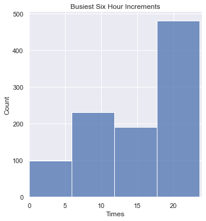

```python
# Import packages
import numpy as np
import pandas as pd
import matplotlib.pyplot as plt

# Read in transactions data
transactions = pd.read_csv("store_transactions.csv")

# Save transaction times to a separate numpy array
times = transactions["T_Time"].values

# Use plt.hist() below
ax = sns.displot(times, bins = 4) # 4 bins
plt.xlim(0,24) # range of data i.e. 0hours to 24 hours
plt.title("Busiest Six Hour Increments")
plt.xlabel("Times")
plt.ylabel("Count")

plt.show();
```

The last six hours of the day are the busiest — from 6 pm until midnight.  
Does this mean the manager should staff their grocery store with the most employees between 6 pm and midnight? To the manager, this doesn’t make much sense. The manager knows the store is busy when many people get off work, but the rush certainly doesn’t continue later than 9 pm. *The issue with this histogram is that we have too few bins.*

**Finding your Best Bin Size**  
When plotting a histogram, it’s essential to select bins that fully capture the trends in the underlying data.  
Often, this will require some guessing and checking. There isn’t much of a science to selecting bin size.  
Let us try changing the "Number of Bins to 24 i.e. each bin is of 1 hour time period.  
We will also add a vertical line for "mean time"

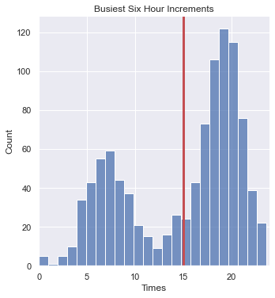

```python
# calculate the mean time
mean_time = np.round(np.mean(times),0)
# Use plt.hist() below
ax = sns.displot(times, bins = 24) # 4 bins
plt.xlim(0,24) # range of data i.e. 0hours to 24 hours
plt.title("Busiest Six Hour Increments")
plt.xlabel("Times")
plt.ylabel("Count")
plt.axvline(mean_time, color='r', linestyle='solid', linewidth=3, label="Mean")
plt.show();
```

**This histogram has two distinct peaks, neither of which are close to our average of 3pm.As you can see, averages don’t tell the full story.By visualizing the shape of our data, we can make better-informed decisions.**

**Looking at the distribution we would recommend increased staffing between 6am to 9am morning and 6pm to 10pm evening since these are the times when store traffic is at it's peak i.e. count of customers is maximum**

**Project : Histograms : Traveling to Acadia**  
Imagine you work at a travel agency and want to inform your customers of the best time to visit one of your favorite vacation locations, Acadia, Maine.

In this project, you will use flower bloom data, and flight information to recommend the best time of year for someone to make a trip to Maine

- in_bloom is a NumPy array containing 900 numbers. Each number is a day of the year, which represents the average start date of a flower blooming.
- flights is a NumPy array with 11,000 numbers. Each number is a day of the year, which represents a flight from your hometown to airports near Acadia, Maine
- Our goal is to create two histograms, each displaying the frequency of an occurrence each day of the year (either flights or flower blooms).
- We will use the in_bloom variable to find a count of the number of flowers that start blooming each day of the year.
- We will use the flights variable to find a count of the number of flights that occur each day of the year

**Load data and calculate average blooms and average flights**

```python
# import packages
import pandas as pd
import numpy as np
import matplotlib.pyplot as plt

# load in data
in_bloom = np.loadtxt(open("in_bloom.csv"), delimiter=",")
flights = np.loadtxt(open("flights.csv"), delimiter=",")

# calculate the mean
b_mean = np.round(np.mean(in_bloom),0)
f_mean = np.round(np.mean(flights),0)
print("Average Blooms per Year in Acadia :" + str(b_mean))
print("Average Flights per Year to Acadia:" + str(f_mean))
```

```
Average Blooms per Year in Acadia :167.0
Average Flights per Year to Acadia:166.0
```

**Histogram of Blooms**

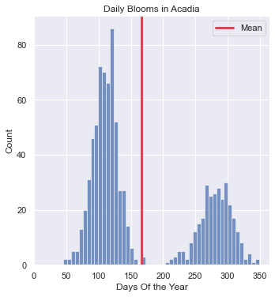

```python
# histogram of in_bloom
ax = sns.displot(in_bloom, bins = 50) # 50 bins
plt.xlim(0,365) # range of data i.e. 0 to 365 days
plt.title("Daily Blooms in Acadia")
plt.xlabel("Days Of the Year")
plt.ylabel("Count")
plt.axvline(b_mean, color='r', linestyle='solid', linewidth=3, label="Mean")

plt.legend()
plt.show();
```

**Histogram of Flights**

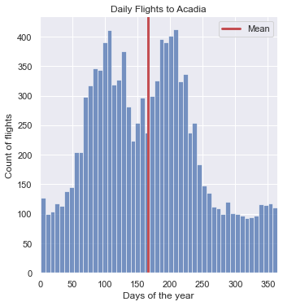

```python
# histogram of flights
sns.displot(flights, bins = 50)
plt.xlim(0,365) # range of data i.e. 0 to 365 days
plt.title("Daily Flights to Acadia")
plt.xlabel("Days of the year")
plt.ylabel("Count of flights")
plt.axvline(f_mean, color='r', linestyle='solid', linewidth=3, label="Mean")

plt.legend()
plt.show();
```

**Comparing both Histograms**

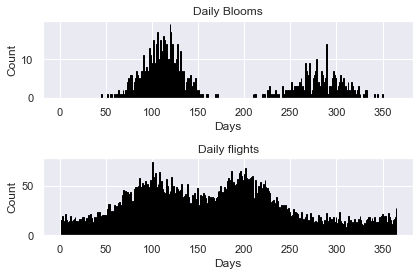

```python
# Plot the histograms for Daily Blooms and Daily Flights
plt.figure(1)
plt.subplot(211)
plt.hist(in_bloom, range = (0, 365), bins = 365, edgecolor='black')

plt.title("Daily Blooms")
plt.xlabel("Days")
plt.ylabel("Count")

plt.subplot(212)
plt.hist(flights, range = (0, 365), bins = 365, edgecolor='black')

plt.title("Daily flights")
plt.xlabel("Days")
plt.ylabel("Count")

plt.tight_layout()
plt.show();
```

*Based on these histograms, I would propose they go between days 250 and 300, which is the Fall.*  
*The flight’s histogram shows fewer flights between these days, while the flowers histogram indicates there should be a number of flowers in bloom during this time*

**Interpretting & Describing a Histogram**  
We interpret a distribution using the following five features of a dataset:

1. Center : **average and median** as our measures of centrality.
2. Spread : **minimum and maximum** values , taken with the mean and median, begin to indicate the shape of the underlying dataset.
3. Skew : data’s **symmetry**
4. Modality : the **number of peaks** in a dataset
5. Outliers : point(s) that are far away from the rest of the dataset

*Identifying Skeweness from a Histogram*

Histogram with one prominent peak, and similar tails to the left and right is called symmetric. **Median~=Mean**  
Histogram with a tail that extends to the right is called a right-skewed dataset. **Median < Mean**  
Histogram with one prominent peak to the right, and a tail that extends to the left is called a left-skewed dataset. **Median > Mean**

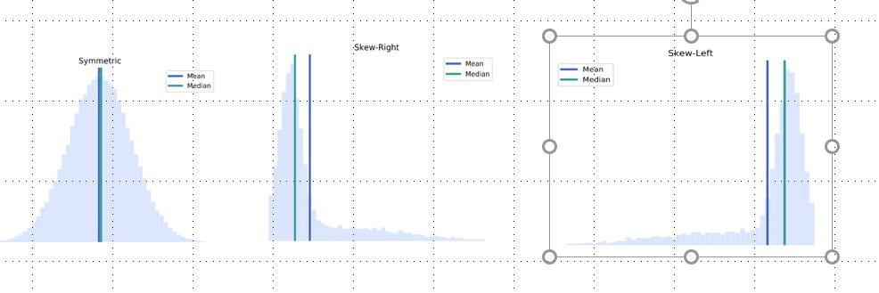

*Identifying Modality from a Histogram*

Histogram with one distinct peak, known as *unimodal* , indicating the most frequent value in a histogram.  
A *bimodal* dataset has two distinct peaks  
A *multimodal* dataset has more than two peaks.  
Datasets with no obvious clustering are called *uniform distributions*

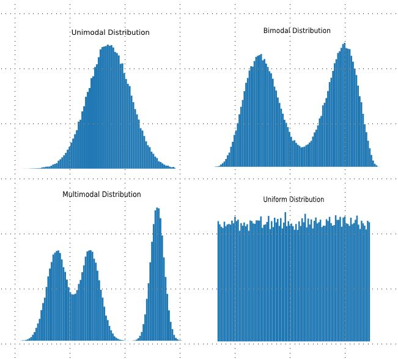

*Identifying Outliers from a Histogram*  
An outlier is a data point that is far away from the rest of the dataset. Ouliers do not have a formal definition, but are easy to determine by looking at histogram  
An outlier in your dataset, is worth reporting and investigating. This data can often indicate an error in your data or an interesting insight  
The histogram below shows an example of an oulier. There is one datapoint that is much larger than the rest

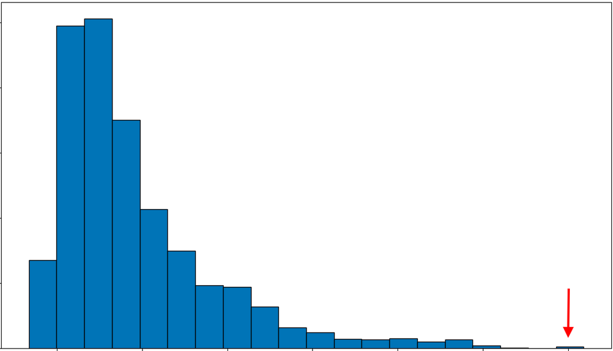

We will use data from the United States Health and Human Services Department to compare the cost of chest pain treatment cross the country..  
**We will look at the distribution of "Average Charges Covered"..**

```python
# import libraries
import pandas as pd
import numpy as np
from scipy import stats
import seaborn as sns
```

```python
# import the data
cp_data = pd.read_csv("chest_pain_treatment.csv")
cp_data.head(2).T
```

|  | 0 | 1 |
| --- | --- | --- |
| PID | 80531 | 82205 |
| DRG Definition | 313 - CHEST PAIN | 313 - CHEST PAIN |
| Provider Id | 220108 | 10001 |
| Provider Name | MILTON HOSPITAL INC | SOUTHEAST ALABAMA MEDICAL CENTER |
| Provider Street Address | 199 REEDSDALE ROAD | 1108 ROSS CLARK CIRCLE |
| Provider City | MILTON | DOTHAN |
| Provider State | MA | AL |
| Provider Zip Code | 2186 | 36301 |
| Hospital Referral Region Description | MA - Boston | AL - Dothan |
| Total Discharges | 43 | 36 |
| Avg_covered_charges | 6760.53 | 19540.5 |
| Average Total Payments | 3547 | 3428.58 |
| Average Medicare Payments | 2633.04 | 2093.38 |

```python
# calculate the min , max , range , mean and the median
cp_min = np.round(cp_data['Avg_covered_charges'].min(),0)
cp_max = np.round(cp_data['Avg_covered_charges'].max(),0)
cp_range = cp_max - cp_min
cp_avg = np.round(cp_data['Avg_covered_charges'].mean(),0)
cp_median = np.round(cp_data['Avg_covered_charges'].median(),0)
print("Minimum Cost :" + str(cp_min))
print("Maximum Cost : " + str(cp_max))
print("Range : " + str(cp_range))
print("Average Cost : " + str(cp_avg))
print("Median Cost :" + str(cp_median))
```

```
Minimum Cost :2459.0
Maximum Cost : 81083.0
Range : 78624.0
Average Cost : 16948.0
Median Cost :14660.0
```

```python
# details of hospital with highest charges
cp_data[cp_data['Avg_covered_charges'] == 81083].T
```

|  | 1272 |
| --- | --- |
| PID | 83476 |
| DRG Definition | 313 - CHEST PAIN |
| Provider Id | 310025 |
| Provider Name | BAYONNE HOSPITAL CENTER |
| Provider Street Address | 29 EAST 29TH ST |
| Provider City | BAYONNE |
| Provider State | NJ |
| Provider Zip Code | 7002 |
| Hospital Referral Region Description | NJ - Newark |
| Total Discharges | 15 |
| Avg_covered_charges | 81083 |
| Average Total Payments | 3817.8 |
| Average Medicare Payments | 2823.6 |

```
Minimum Cost : USD 2,459
Maximum Cost : USD 81,083
Range : 78624.0
Average Cost : 16948.0
Median Cost :14660.0
```

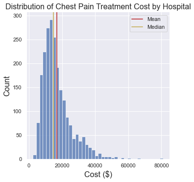

```python
# plotting the histogram
sns.displot(cp_data["Avg_covered_charges"] , bins = 40)
plt.title("Distribution of Chest Pain Treatment Cost by Hospital", fontsize = 16)
plt.xlabel("Cost ($)", fontsize = 16)
plt.ylabel("Count", fontsize = 16)
plt.axvline(cp_avg, color='r', linestyle='solid', linewidth=2, label="Mean")
plt.axvline(cp_median, color='y', linestyle='solid', linewidth=2, label="Median")
plt.legend()
print("Minimum Cost : USD 2,459")
print("Maximum Cost : USD 81,083")
print("Range : " + str(cp_range))
print("Average Cost : " + str(cp_avg))
print("Median Cost :" + str(cp_median))
plt.show();
```

**Description and Interpretation**

- This histogram displays the distribution of chest pain cost for over 2,000 hospitals across the United States. The average and median costs are USD16,948 and USD14,659.6, respectively. Given that the data is unimodal, with one local maximum and a right skew, the fact that the average is greater than the median, matches our expectation.
- The range of costs is very large, USD78,624, with the smallest cost equal to USD2,459 and the largest cost equal to USD81,083. There is one hospital "BAYONNE HOSPITAL CENTER" that charges far more than the rest at USD81,083.

## Quartiles

A common way to communicate a high-level overview of a dataset is to find the values that split the data into four groups of equal size.By doing this, we can then say whether a new datapoint falls in the first, second, third, or fourth quarter of the data.The values that split the data into fourths are the quartiles.Those values are called the first quartile (Q1), the second quartile (Q2), and the third quartile (Q3).

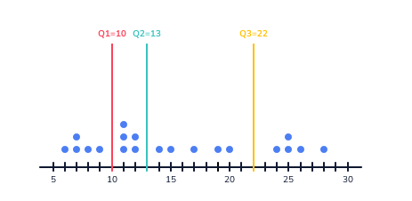

In the image above, Q1 is 10, Q2 is 13, and Q3 is 22. Those three values split the data into four groups that each contain five datapoints. **Q2 happens to be exactly the median.To find Q1, we take all of the data points smaller than Q2 and find the median of those points.To find Q3, we take all of the data points that are larger than Q2 and find the median of those points**

We’ve plotted a histogram of song lengths (measured in seconds) of 9,975 random songs.We’ve picked one of with a playing time 364 seconds long and plotted it as a red vertical line.

```python
songsdf = pd.read_csv("songsdf.csv")
songsdf.head()
```

|  | Length |
| --- | --- |
| 0 | 218.93179 |
| 1 | 148.03546 |
| 2 | 177.47546 |
| 3 | 233.40363 |
| 4 | 209.60608 |

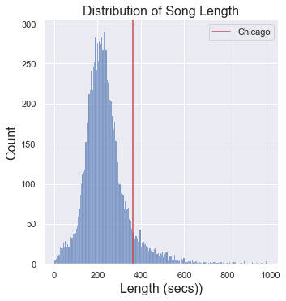

```python
# plotting the histogram
sns.displot(songsdf["Length"] , bins = 200)
plt.title("Distribution of Song Length", fontsize = 16)
plt.xlabel("Length (secs))", fontsize = 16)
plt.ylabel("Count", fontsize = 16)
plt.axvline(x=364, label="Chicago", c = 'r')
plt.legend()
plt.show();
```

There is a function named **quantile()** in the NumPy library that will us find the quartiles.  
syntax : np.quantile(dataset, 0.75)  
The quantile() function takes two parameters.

- The first is the dataset you’re interested in.
- The second is a number between 0 and 1.

**1st Quartile = 0.25 , 3rd Quartile = 0.75 and 2nd Quartile = 0.5**

```python
#Create the variables songs_q1, songs_q2, and songs_q3 here:
songs_q1 = np.quantile(songsdf , 0.25)
songs_q2 = np.quantile(songsdf , 0.5)
songs_q3 = np.quantile(songsdf , 0.75)

#Print the quartiles:
print("The first quartile of Songs " + str(songs_q1) + " seconds")
print("The second quartile of Songs " + str(songs_q2)+ " seconds")
print("The third quartile of Songs " + str(songs_q3)+ " seconds")
```

```
The first quartile of Songs 175.93424 seconds
The second quartile of Songs 222.82404 seconds
The third quartile of Songs 275.47383 seconds
```

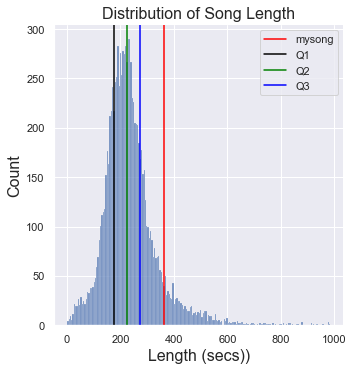

```python
# plotting the histogram
sns.displot(songsdf["Length"] , bins = 200)
plt.title("Distribution of Song Length", fontsize = 16)
plt.xlabel("Length (secs))", fontsize = 16)
plt.ylabel("Count", fontsize = 16)
plt.axvline(x=364, label="mysong", c = 'red')
plt.axvline(x=176, label="Q1", c = 'black')
plt.axvline(x=223, label="Q2", c = 'green')
plt.axvline(x=275, label="Q3", c = 'blue')
plt.legend()
plt.show();
```

**Our selected song falls in the 4th Quartile**

Quartiles are some of the most commonly used descriptive statistics. For example, You might see schools or universities think about quartiles when considering which students to accept. Businesses might compare their revenue to other companies by looking at quartiles.

**The three quartiles, along with the minimum and the maximum values of a dataset, are called the *five-number summary* of the dataset**.

These five numbers help you quickly get a sense of the range, centrality, and spread of the dataset.

## Quantiles

**Quantiles are values that split a dataset into groups of equal size**.

Let’s say you just took a test and wanted to know whether you’re in the top 10% of the class. One way to determine this would be to split the data into ten groups with an equal number of datapoints in each group and see which group you fall into.There are nine values that split the dataset into ten groups of equal size.Those nine values that split the data are quantiles! Specifically, they are the 10-quantiles, or **deciles**.

You can find any number of quantiles. For example, if you split the dataset into 100 groups of equal size, the 99 values that split the data are the 100-quantiles, or percentiles

**If you have n quantiles, the dataset will be split into n+1 groups of equal size.**  
**The median is a quantile. It is the only 2-quantile. Half the data falls below the median and half falls above the median**  
**Quartiles split the data into 4 groups while Percentiles split the data into 100 groups.**

```python
# twenty_third_percentile of songs:
twenty_third_percentile = np.quantile(songsdf , 0.23)

print("The value that splits 23% of the data is " + str(twenty_third_percentile) + "\n")
```

```
The value that splits 23% of the data is 171.7812924
```

```python
# quartiles and deciles of songs data
# Define quartiles, deciles, and tenth here:
quartiles = np.quantile(songsdf , [0.25,0.5,0.75])
deciles = np.quantile(songsdf , [0.1,0.2,0.3,0.4,0.5,0.6,0.7,0.8,0.9])

#print the qartiles and deciles:
print("The quariles are " + str(quartiles) + "\n")
print("The deciles are " + str(deciles) + "\n")
```

```
The quariles are [175.93424 222.82404 275.47383]

The deciles are [135.151876 165.375546 185.99138  204.815222 222.82404  240.22159
 262.47791  290.95138  348.493912]
```

```python
print("My Song of length 170 falls in the 3rd quantile")
```

```
My Song of length 170 falls in the 3rd quantile
```

## Interquartile Range (IQR)

The interquartile range (IQR), also called the midspread, middle 50%, or H‑spread, is a measure of statistical dispersion, being equal to the difference between 75th and 25th percentiles, or between upper and lower quartiles.**IQR = Q3 − Q1**  
The **first quartile Q1** is the value that separates the **first 25%** of the data from the remaining 75%.  
The **third quartile Q3** is the opposite of Q1 — it separates the **first 75%** of the data from the remaining 25%.

The SciPy library has a function **iqr()** in the "stats" package that can calculate the IQR.

```python
from scipy.stats import iqr

dataset = [4, 10, 38, 85, 193]
interquartile_range = iqr(dataset)
interquartile_range
```

```
75.0
```

The main takeaway of the IQR is that it is a statistic, like the range, that helps describe the spread of the center of the data.

However, unlike the range, the IQR is robust. A statistic is robust when outliers have little impact on it.

For example, the IQRs of the two datasets below are identical, even though one has a massive outlier.  
dataset_one = [6, 9, 10, 45, 190, 200] #IQR is 144.5  
dataset_two = [6, 9, 10, 45, 190, 20000000] #IQR is 144.5

**By looking at the IQR instead of the range, you can get a better sense of the spread of the middle of the data**

## Project : Life Expectancy

Over the course of the past few centuries, technological and medical advancements have helped increase the life expectancy of humans. However, as of now, the average life expectancy of humans varies depending on what country you live in.

In this project, we will investigate a dataset containing information about the average life expectancy in 158 different countries. We will specifically look at how a country’s economic success might impact the life expectancy in that area

**Access the data**

```python
# import the packages
import pandas as pd
import numpy as np
import scipy.stats as sp
import matplotlib.pyplot as plt
import seaborn as sns
%matplotlib inline
```

```python
# load the data and review top 5 rows
data = pd.read_csv("country_data.csv")
data.head()
```

|  | Country | Life Expectancy | GDP |
| --- | --- | --- | --- |
| 0 | Afghanistan | 58.19375 | 340.015425 |
| 1 | Albania | 75.15625 | 2119.726679 |
| 2 | Algeria | 73.61875 | 2847.853392 |
| 3 | Angola | 49.01875 | 1975.143045 |
| 4 | Antigua and Barbuda | 75.05625 | 9759.305728 |

**Analysing Life Expectancy**

```python
# extract column Life Expectancy
Life_Expectancy = data['Life Expectancy']

# apply np.quantile function to extract quartiles
LE_quartiles = np.quantile(Life_Expectancy , [0.25, 0.5, 0.75])

# print results
print(LE_quartiles)
```

```
[62.325     72.525     75.4421875]
```

Q1:62 Years , Q2:73 Years , Q3: 75 Years

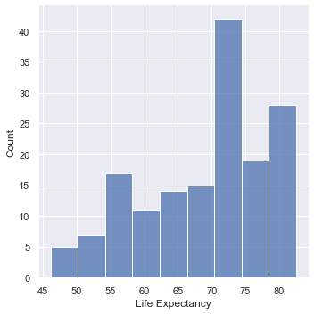

```python
# plot the histogram
sns.displot(Life_Expectancy);
```

Looking at the Quartile values , the narrowest quartile is between 72 and 75 years , which is visible as a large spike in the histogram around 75

**Analysing GDP : Country's Wealth**  
Let’s split the data into two groups based on GDP , "Low GDP countries < Median" and “High GDP countries > Median"

```python
# create a dataset with gdp only
country_gdp = data['GDP']

# calculate the median
median_gdp = np.quantile(country_gdp , 0.5)

print(median_gdp)
```

```
2938.0781155000004
```

```python
# create a dataset with GDP<median
low_gdp = data[data['GDP'] <= median_gdp]

# create a dataset with GDP>median
high_gdp = data[data['GDP'] > median_gdp]
```

```python
print("Summary of GDP and Life Expectancy for Low GDP Countries")
print(low_gdp.describe())
print("---------------------------------------------------------")
print("Summary of GDP and Life Expectancy for High GDP Countries")
print(high_gdp.describe())
print("---------------------------------------------------------")
```

```
Summary of GDP and Life Expectancy for Low GDP Countries
       Life Expectancy          GDP
count        79.000000    79.000000
mean         63.292273  1104.062071
std           8.204108   788.291567
min          46.112500   137.815321
25%          56.337500   410.676114
50%          64.343750   801.912383
75%          71.737500  1955.767241
max          75.968750  2928.543542
---------------------------------------------------------
Summary of GDP and Life Expectancy for High GDP Countries
       Life Expectancy           GDP
count        79.000000     79.000000
mean         75.204747  13674.061140
std           6.068401  12430.475237
min          55.312500   2947.612689
25%          72.965625   4686.353328
50%          75.156250   7902.410789
75%          80.521875  20489.795235
max          82.537500  57362.874600
---------------------------------------------------------
```

**Life Expectancy : Median Life Expectancy 64 Years for Low GDP ountries is lower than that of High GDP Countries**  
**GDP(Wealth) : Median GDP 801 for Low GDP countries is significantly lower than that of High GDP Countires**

**Histogram of GDP and Life Expectancy**

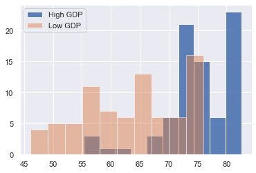

```python
fig, ax = plt.subplots(1, 1)

ax.hist(high_gdp["Life Expectancy"], alpha=0.9, label='High GDP')
ax.hist(low_gdp["Life Expectancy"], alpha=0.5, label='Low GDP')
ax.legend(loc='upper left')

plt.show();
```

**Histogram clearly revelas the impact GDP has on life expectancy.**

## Box Plots : Centre-Spread-Outliers

A boxplot is a standardized way of displaying the distribution of data based on a five number summary (“minimum”, first quartile (Q1), median, third quartile (Q3), and “maximum”). It can tell you about your outliers and what their values are. It can also tell you if your data is symmetrical, how tightly your data is grouped, and if and how your data is skewed.

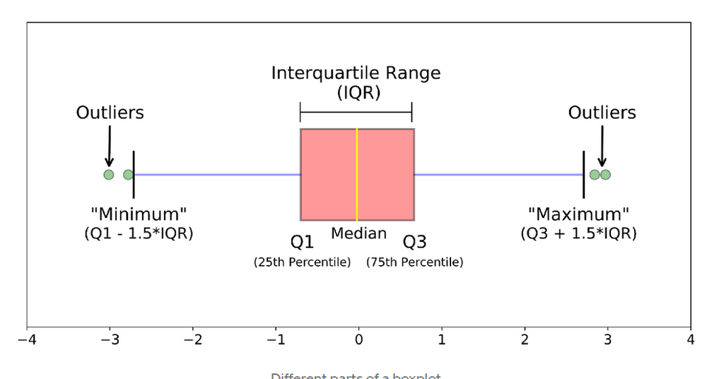

Constituents of a Boxplot include :

1. Median (Q2/50th Percentile): the middle value of the dataset.
2. First quartile (Q1/25th Percentile): the middle number between the smallest number (not the “minimum”) and the median of the dataset.
3. Third quartile (Q3/75th Percentile): the middle value between the median and the highest value (not the “maximum”) of the dataset.
4. Interquartile range (IQR): 25th to the 75th percentile.
5. Whiskers (shown in blue) : Generally whiskers lie 1.5 times the interquartile range from the first and third quartile i.e. Qx+/-1.5(IQR)
6. Outliers (shown as green circles) : Outliers are points that fall beyond the whiskers.

**Drawing Boxplots with Seaborn**

We’ve imported the dataset of song lengths, but this time, we’ve split the data into three groups — songs that were released in the year 2000 (s2000), songs that were released in the year 2001 (s2001), and songs that were released in the year 2002 (s2002).

We will plot all three datasets as three separate boxplots in the same order described above to compare them side-by-side

```python
# import the packages
import pandas as pd
import numpy as np
import matplotlib.pyplot as plt
import seaborn as sns
%matplotlib inline
```

```python
# load the data
s2000 = pd.read_csv("songs_2000.csv")
s2001 = pd.read_csv("songs_2001.csv")
s2002 = pd.read_csv("songs_2002.csv")
s2000.head()
s2001.head()
s2002.head()
```

|  | Yr2000 |
| --- | --- |
| 0 | 165.61587 |
| 1 | 273.52771 |
| 2 | 426.89261 |
| 3 | 385.33179 |
| 4 | 187.53261 |

|  | Yr2001 |
| --- | --- |
| 0 | 233.27302 |
| 1 | 124.18567 |
| 2 | 292.83220 |
| 3 | 219.01016 |
| 4 | 127.94730 |

|  | Yr2002 |
| --- | --- |
| 0 | 195.31710 |
| 1 | 194.11546 |
| 2 | 224.28689 |
| 3 | 239.98649 |
| 4 | 188.39465 |

```python
# combine all data sets into one dataframe
combined=pd.concat([s2000,s2001,s2002])
combined.info()
```

```
<class 'pandas.core.frame.DataFrame'>
Int64Index: 607 entries, 0 to 197
Data columns (total 3 columns):
 #   Column  Non-Null Count  Dtype
---  ------  --------------  -----
 0   Yr2000  192 non-null    float64
 1   Yr2001  217 non-null    float64
 2   Yr2002  198 non-null    float64
dtypes: float64(3)
memory usage: 19.0 KB
```

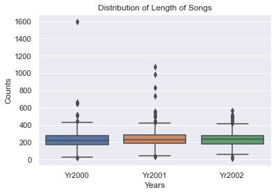

```python
## pd.melt converts a wide-form dataframeto long-form
## generate the box plot with x and y values
ax = sns.boxplot(x="variable", y="value", data=pd.melt(combined))
## add the title
ax.set_title('Distribution of Length of Songs')
## add the y-axis label
ax.set_ylabel('Counts')
## add the x-axis label
ax.set_xlabel("Years")
## display the plot
plt.show();
```

**Interpretation**  
1) The three boxplots show that there is very little difference in spread between the three years.  
2) The median and interquartile range are almost identical across all three years.  
3) There was one significant outlier in 2000.  
4) 2001 had many outliers that were fairly spread out  
5) 2002 had many outliers, but they weren’t absurdly far from the median